# Exercise 2

```r
date()
```

```
## [1] "Mon Nov  6 15:24:44 2023"
```

In this exercise, I analyze data obtained from a questionnare related to learning approaches and student achievements.The data was collected in a statistics course in Fall 2014.

I first go through the basic information about the dataset. Next, I try to find statistically significant variables that would explaine the exam points of the students. Even though in the exercise it says that you should use 3 explanatory variables, I could only find one variable that is statistically significant, which is “attitude towards statistics”. At least the result is not counter-intuitive, as it is clearly shown in the data that positive attitude towards statistics will yield more point from the exam.

I ended up using a linear regression model, and it does not look like there would be a better fit with more advanced models (polynomial for example). The students attitude towards statistics explains around 19% of the total exam points obtained. That is not very high, which implies that other factors surely affect the exam points.

```r
students2014<- read.csv("data/learning2014.csv", header = TRUE, sep = ",")
str(students2014)
```

```
## 'data.frame':    166 obs. of  7 variables:
##  $ gender  : chr  "F" "M" "F" "M" ...
##  $ Age     : int  53 55 49 53 49 38 50 37 37 42 ...
##  $ Attitude: num  3.7 3.1 2.5 3.5 3.7 3.8 3.5 2.9 3.8 2.1 ...
##  $ Points  : int  25 12 24 10 22 21 21 31 24 26 ...
##  $ deep    : num  3.58 2.92 3.5 3.5 3.67 ...
##  $ stra    : num  3.38 2.75 3.62 3.12 3.62 ...
##  $ surf    : num  2.58 3.17 2.25 2.25 2.83 ...
```

```r
dim(students2014)
```

```
## [1] 166   7
```

Our data has 166 observations for each 7 variables: Gender, age, attitude, points, deep, stra and surf. While gender and age are self-explanatory, here is some information about the rest of the variables: Attitude: General attitude towards statistics. Is a mean of 10 separate questions.

Deep: A combination variable of three question sets: 4 questions related to “seeking meaning”, 4 questions related to “relating ideas”, and 4 questions related to #use of evidence”.

Stra: A combination variable of 8 questions related to time management and organized studying, in other words “how strategic is the learning approach of the student”

Surf: A combination variable of 12 questions related to “surface approach”, i.e., how shallow is the learning approach of the student.

Points: Points for the course exam.

Let us next present some graphs of the data:

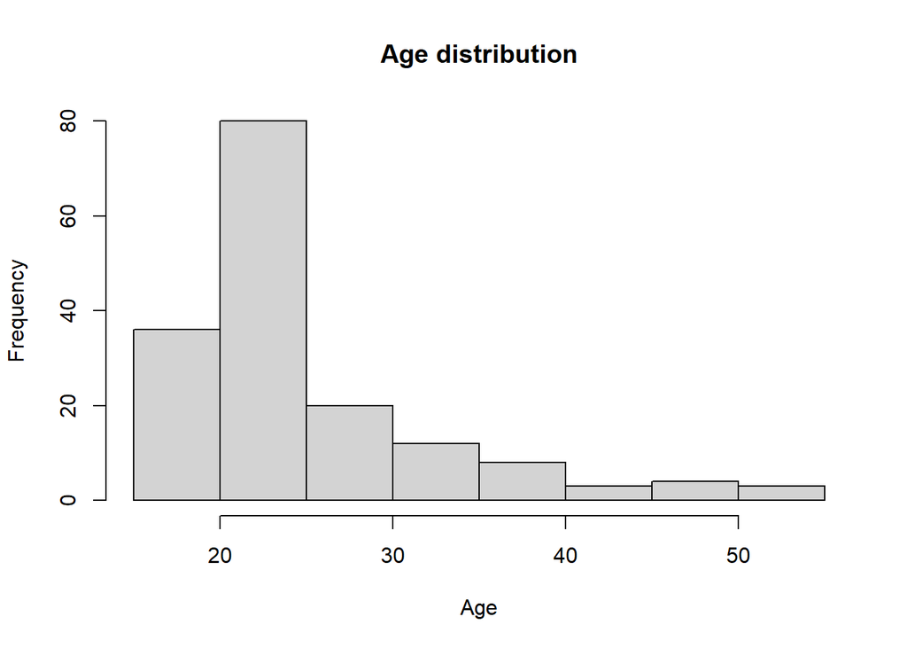

```r
hist(students2014$Age, main="Age distribution", xlab="Age")
```

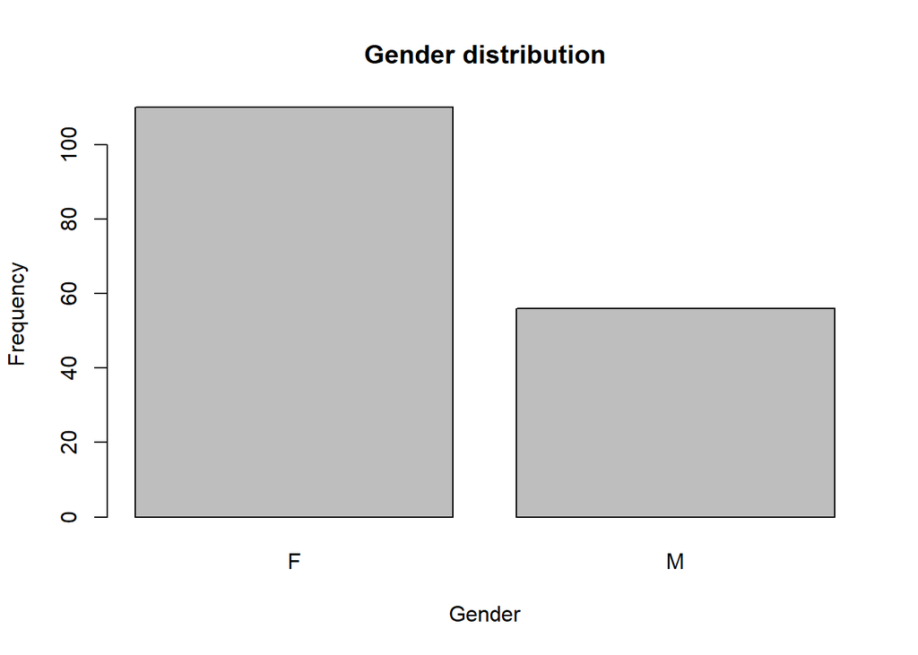

```r
barplot(table(students2014$gender), main="Gender distribution", xlab="Gender", ylab="Frequency")
```

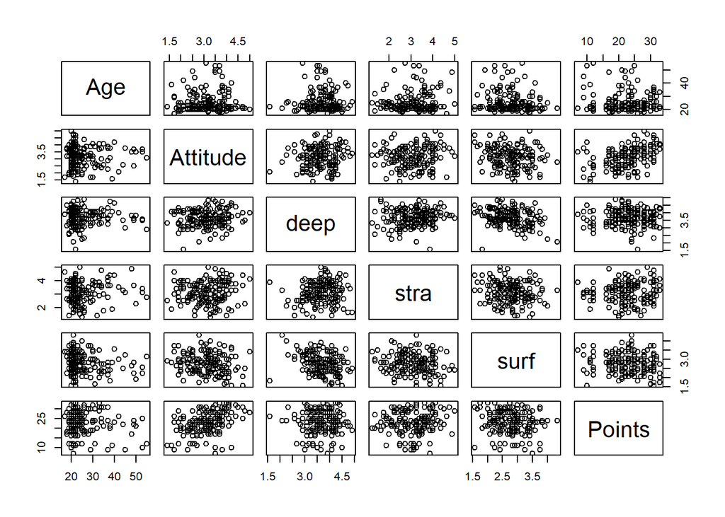

```r
pairs(students2014[, c("Age", "Attitude", "deep", "stra", "surf", "Points")])
```

As expected, our dataset consists mostly of young participants (20-30 yr), as the data was collected from an university course. The number of female respondents is considerably higher than the number of male respondents. A quick representation of all datapairs does not reveal anything significant at least at first glance. One hypothesis would be that older people would have a more strategic approach towards learning. The datapairs perhaps reveals this kind of tendency, but it should be studied further in the next sections. Also we can see a slight tendency that strategic learners got higher points from the exam than surface learners.

The summary of our data

```r
summary(students2014)
```

```
##     gender               Age           Attitude         Points
##  Length:166         Min.   :17.00   Min.   :1.400   Min.   : 7.00
##  Class :character   1st Qu.:21.00   1st Qu.:2.600   1st Qu.:19.00
##  Mode  :character   Median :22.00   Median :3.200   Median :23.00
##                     Mean   :25.51   Mean   :3.143   Mean   :22.72
##                     3rd Qu.:27.00   3rd Qu.:3.700   3rd Qu.:27.75
##                     Max.   :55.00   Max.   :5.000   Max.   :33.00
##       deep            stra            surf
##  Min.   :1.583   Min.   :1.250   Min.   :1.583
##  1st Qu.:3.333   1st Qu.:2.625   1st Qu.:2.417
##  Median :3.667   Median :3.188   Median :2.833
##  Mean   :3.680   Mean   :3.121   Mean   :2.787
##  3rd Qu.:4.083   3rd Qu.:3.625   3rd Qu.:3.167
##  Max.   :4.917   Max.   :5.000   Max.   :4.333
```

The age variation is rather large, while the median age is 22. Perhaps an interesting finding from the summary is that points for strategic learning is more spread out than the points for surface learning.

Let us next choose three variables as explanatory variables and fit a regression model where the exam points is the target variable. I hypothesize that attitude and strategic learning has statistically significant, positive effect on the exam points, while surface learning has significant negative effect.

```r
regressionpoints <- lm(Points ~ Attitude + stra + surf, data=students2014)
summary(regressionpoints)
```

```
##
## Call:
## lm(formula = Points ~ Attitude + stra + surf, data = students2014)
##
## Residuals:
##      Min       1Q   Median       3Q      Max
## -17.1550  -3.4346   0.5156   3.6401  10.8952
##
## Coefficients:
##             Estimate Std. Error t value Pr(>|t|)
## (Intercept)  11.0171     3.6837   2.991  0.00322 **
## Attitude      3.3952     0.5741   5.913 1.93e-08 ***
## stra          0.8531     0.5416   1.575  0.11716
## surf         -0.5861     0.8014  -0.731  0.46563
## ---
## Signif. codes:  0 '***' 0.001 '**' 0.01 '*' 0.05 '.' 0.1 ' ' 1
##
## Residual standard error: 5.296 on 162 degrees of freedom
## Multiple R-squared:  0.2074, Adjusted R-squared:  0.1927
## F-statistic: 14.13 on 3 and 162 DF,  p-value: 3.156e-08
```

From the explanatory variables Attitude, stra and surf, only Attitude seems statistically significant based on a linear regression model. Let us consider a scatter plot of the variables to see whether there are any linear patterns, or whether we should try polynomial regression:

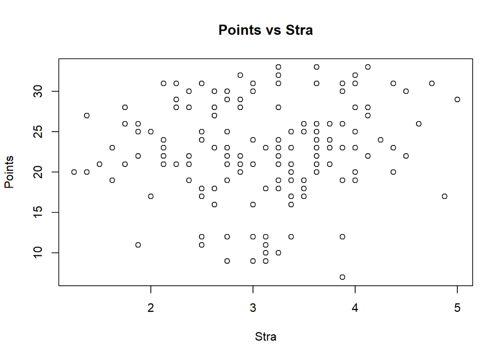

```r
plot(students2014$stra, students2014$Points, main="Points vs Stra", xlab="Stra", ylab="Points")
```

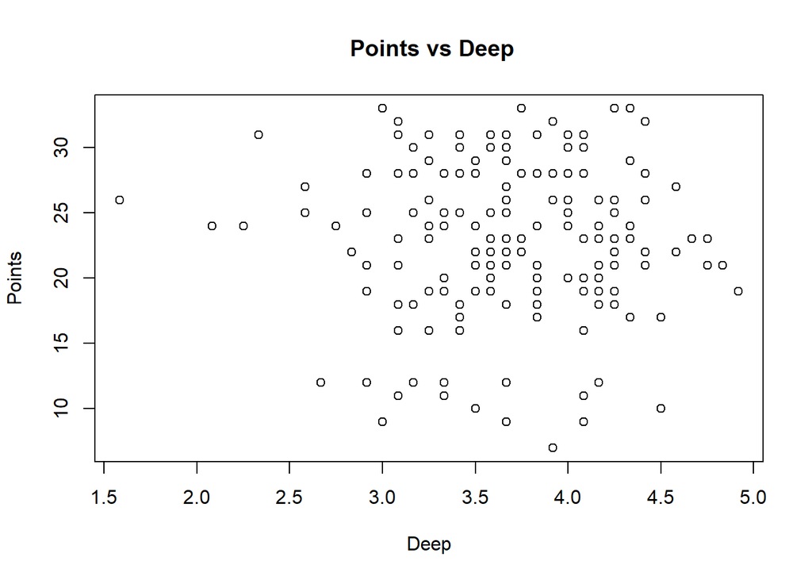

```r
plot(students2014$deep, students2014$Points, main=" Points vs Deep", xlab="Deep", ylab="Points")
```

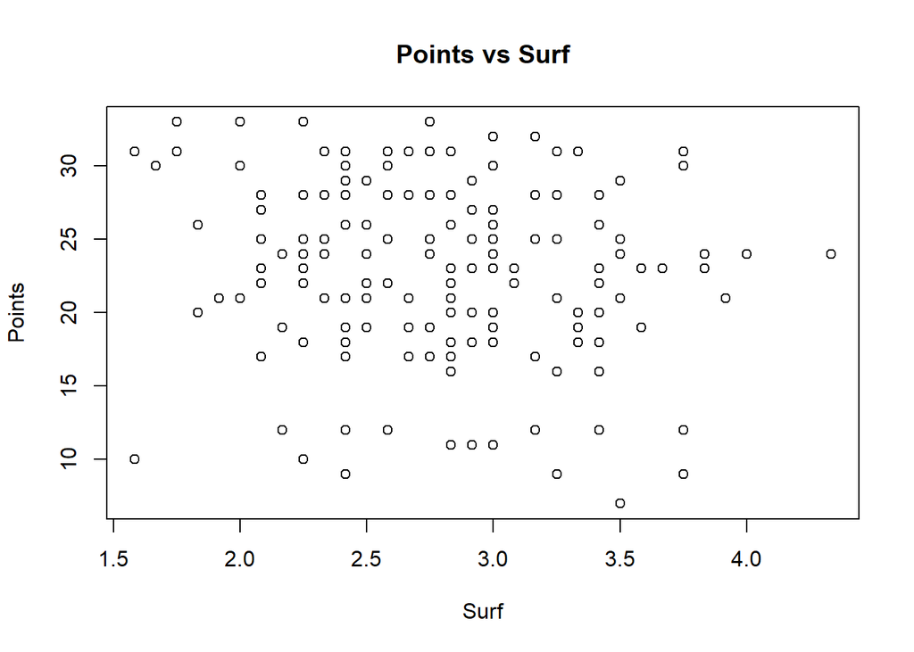

```r
plot(students2014$surf, students2014$Points, main="Points vs Surf", xlab="Surf", ylab="Points")
```

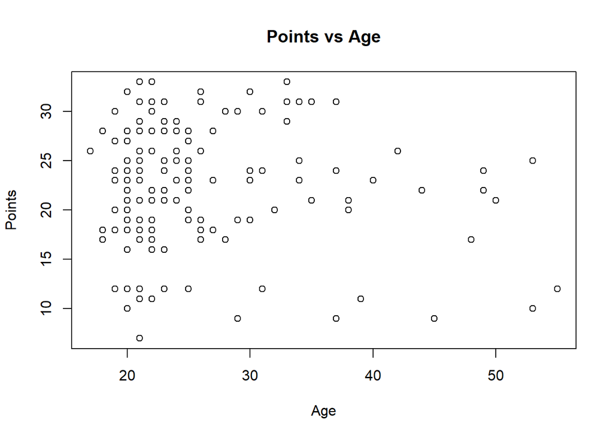

```r
plot(students2014$Age, students2014$Points, main="Points vs Age", xlab="Age", ylab="Points")
```

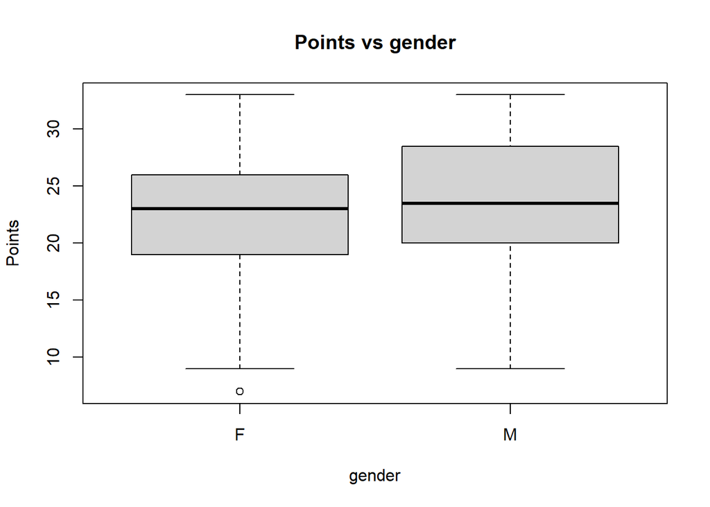

```r
boxplot(students2014$Points ~ students2014$gender, main="Points vs gender", xlab="gender", ylab="Points")
```

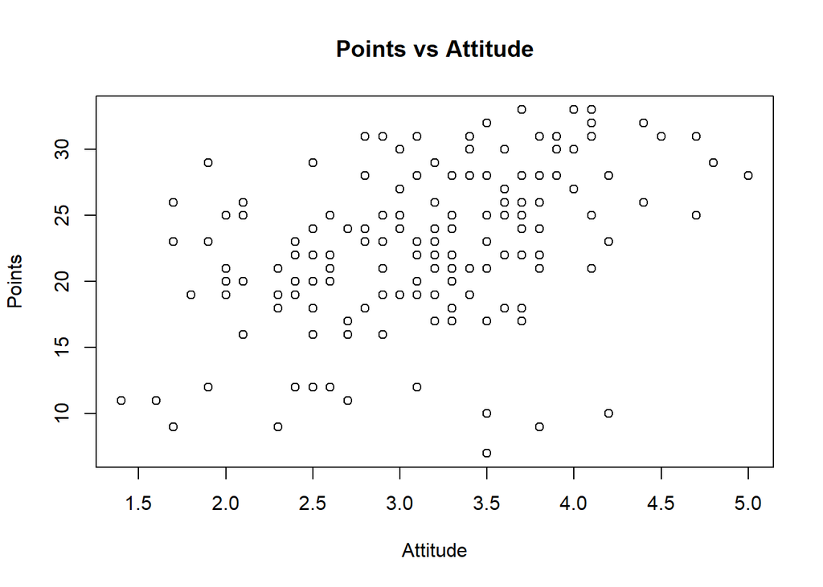

```r
plot(students2014$Attitude, students2014$Points, main="Points vs Attitude", xlab="Attitude", ylab="Points")
```

Based on graphical presentation, it really seems that Attitude is the only variable that has a linear effect on the exam points. It is also quite clear that there are no nonlinear dependencies. Let us try other variable constellations:

```r
regressionpoints <- lm(Points ~ Attitude, data=students2014)
summary(regressionpoints)
```

```
##
## Call:
## lm(formula = Points ~ Attitude, data = students2014)
##
## Residuals:
##      Min       1Q   Median       3Q      Max
## -16.9763  -3.2119   0.4339   4.1534  10.6645
##
## Coefficients:
##             Estimate Std. Error t value Pr(>|t|)
## (Intercept)  11.6372     1.8303   6.358 1.95e-09 ***
## Attitude      3.5255     0.5674   6.214 4.12e-09 ***
## ---
## Signif. codes:  0 '***' 0.001 '**' 0.01 '*' 0.05 '.' 0.1 ' ' 1
##
## Residual standard error: 5.32 on 164 degrees of freedom
## Multiple R-squared:  0.1906, Adjusted R-squared:  0.1856
## F-statistic: 38.61 on 1 and 164 DF,  p-value: 4.119e-09
```

Based on numerous iterations, it seems like the variables attitude is the only significant variable. p value is extremely small, implying the significance of the effect of Attitude. Given the estimate of attitude 3.5255, it implies that for each unit of increase in attitude, the points obtained from the exam increases by 3.5255, with a standard error 0.5674.

The multiple R-squared is 0.1906, which implies that around 19% of the variance in exam points can be explained by attitude. Adjusted R-square takes into account the number of variables and sample size, which decreases the effect of attitude to 18.5%.

Based on our results, the attitude towards statistics is a significant predictor of the exam results. However, it only explains 18.5% of the exam points. This suggests that there are definitely other factors as well that explain the variance in points.

Last, we do the diagnostic plots:

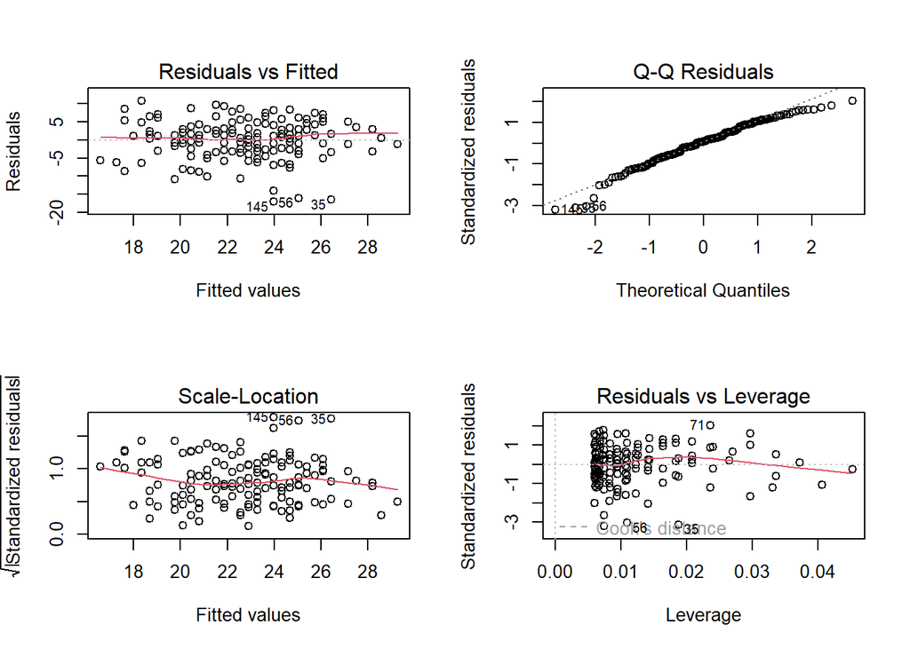

```r
par(mfrow = c(2, 2))  # Set up the graphics layout
plot(regressionpoints)  # This command will produce four plots
```

Residuals vs. fitted checks the linearity and homoscedasticity assumptions of our model. as there are no clear pattern in the scattered plots, we can conclude that the linearity and homoscedasticity assumption are valid.

In Q-Q residuals, we check the normality of residuals.As in, it tells essentially the difference between the predicted value and the actual value. In other words, the “error” in the predicted value of our model. As the data points follow closely the reference line, the assumpotion is valid.

Scale-Location is used to check the homoscedasticity, similarly as in the residuals vs. fitted. Homoscedasticity imply that the variance of the data is the same all over the data. As the residuals are spread somewhat equally, this assumption holds.

```r
# Assuming the data frame is named students2014 and you want row 71
attitude_value <- students2014[71, "Attitude"]
points_value <- students2014[71, "Points"]

# Print the values
print(paste("Attitude:", attitude_value))
```

```
## [1] "Attitude: 1.9"
```

```r
print(paste("Points:", points_value))
```

```
## [1] "Points: 29"
```

While the mean for attitude is 3.143, and mean for points is 22.72, it seems like the participant 71 has remarkably negative attitude towards statistics and still got excellent exam points. Luckily the majority of participants follow our model results, and as we know, the exception proves the rule.